# Statistical Inference Peer Assessment Part 2 of 2

Joe Cannon

October 19, 2015

## Effect of different Viamin C delivery methods in guinea pig tooth growth

### Overview

Dataset: The response is the length of odontoblasts (cells responsible for tooth growth) in 60 guinea pigs. Each animal received one of three dose levels of vitamin C (0.5, 1, and 2 mg/day) by one of two delivery methods, (orange juice or ascorbic acid (a form of vitamin C and coded as VC).

This part of the project I will - Load the ToothGrowth data and perform some basic exploratory data analyses - Provide a basic summary of the data. - Used confidence intervals and/or hypothesis tests to compare tooth growth by supp and dose. - State my conclusions and the assumptions needed for your conclusions.

#### 1.) Load ToothGrowth data

```r
data(ToothGrowth)
toothGrowth <- ToothGrowth
toothGrowth$dose <- as.numeric(toothGrowth$dose) # convert to factor
toothGrowth$len <- as.numeric(toothGrowth$len)
```

#### 2.) Basic Summary of the data

```r
str(toothGrowth)
```

```
## 'data.frame':    60 obs. of  3 variables:
##  $ len : num  4.2 11.5 7.3 5.8 6.4 10 11.2 11.2 5.2 7 ...
##  $ supp: Factor w/ 2 levels "OJ","VC": 2 2 2 2 2 2 2 2 2 2 ...
##  $ dose: num  0.5 0.5 0.5 0.5 0.5 0.5 0.5 0.5 0.5 0.5 ...
```

```r
summary(toothGrowth)
```

```
##       len        supp         dose
##  Min.   : 4.20   OJ:30   Min.   :0.500
##  1st Qu.:13.07   VC:30   1st Qu.:0.500
##  Median :19.25           Median :1.000
##  Mean   :18.81           Mean   :1.167
##  3rd Qu.:25.27           3rd Qu.:2.000
##  Max.   :33.90           Max.   :2.000
```

```r
head(toothGrowth)
```

```
##    len supp dose
## 1  4.2   VC  0.5
## 2 11.5   VC  0.5
## 3  7.3   VC  0.5
## 4  5.8   VC  0.5
## 5  6.4   VC  0.5
## 6 10.0   VC  0.5
```

Create and average length for each dose, and suppliment

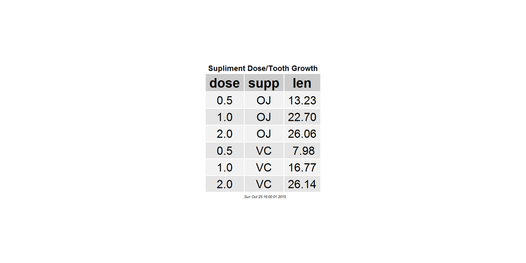

```r
ATG <- aggregate(len~dose+supp,toothGrowth,mean)

  mytheme <- gridExtra::ttheme_default(
      core = list(fg_params=list(cex = 1.3)),
      colhead = list(fg_params=list(cex = 1.5)),
      rowhead = list(fg_params=list(cex = .5)))

  table <- gridExtra::tableGrob(ATG, theme = mytheme,rows = NULL)
  title <- textGrob("Supliment Dose/Tooth Growth",gp=gpar(fontsize=10,fontface="bold"))

  footnote <- textGrob(date() , x=0, hjust=0,
                       gp=gpar( fontface="italic",fontsize=5),just = 0)
  padding <- unit(.5,"line")
  table <- gtable_add_rows(table,
                           heights = grobHeight(title) + padding,
                           pos = 0)
  table <- gtable_add_rows(table,
                           heights = grobHeight(footnote)+padding)


  table <- gtable_add_grob(table, list(title,footnote),
                           t=c(1, nrow(table)), l=c(1,2),
                           r=ncol(table))


  grid.newpage()
  grid.draw(table)
```

This is the result of the average tooth growth based on dose of supp.

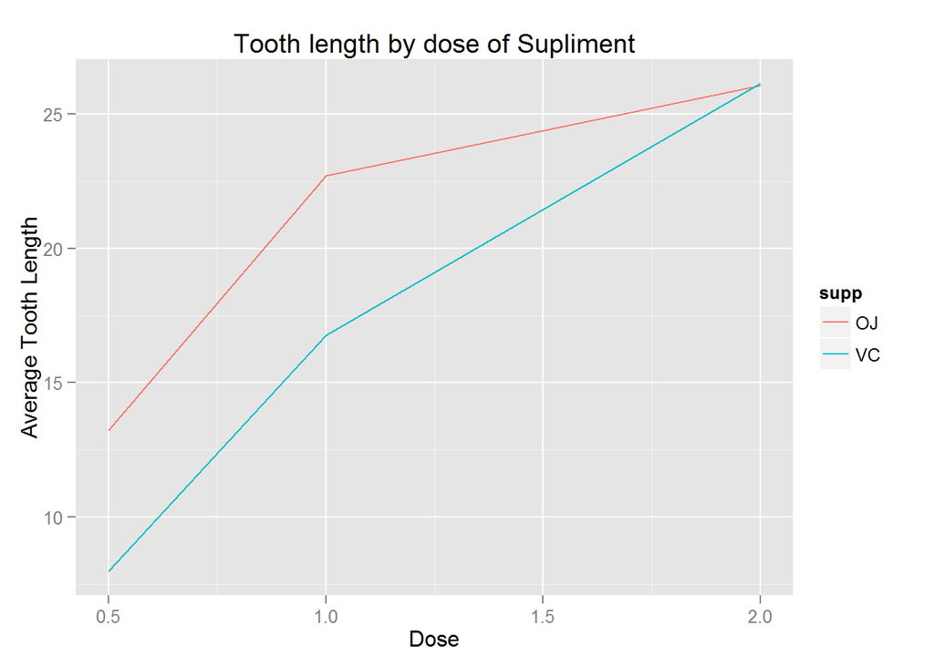

```r
ggplot(ATG, aes(x=dose,y=len,colour=supp),size=2) +
    geom_line() +
    ggtitle("Tooth length by dose of Supliment")+
    xlab("Dose")+
    ylab("Average Tooth Length")
```

### 3.) Use confidence intervals and/or hypothesis tests to compare tooth growth by supp and dose. (Only use the techniques from class, even if there’s other approaches worth considering)

```r
test1 <- t.test(len~supp, paired=F, var.equal=T, data=ToothGrowth[which(ToothGrowth$dose==.5),])
test2 <- t.test(len~supp, paired=F, var.equal=F, data=ToothGrowth[which(ToothGrowth$dose==.5),])


result <- data.frame("conf"=c(attr(test1$conf,"conf.level"),attr(test2$conf,"conf.level")),
                     "p_value"=c(test1$p.value, test2$p.value),
                     "conf_low"=c(test1$conf[1],test2$conf[1]),
                     "conf_high"=c(test1$conf[2],test2$conf[2]),
                      row.names=c("Equal Var","Unequal Var"))
plow <- min(result$p_value)
phigh <- max(result$p_value)
```

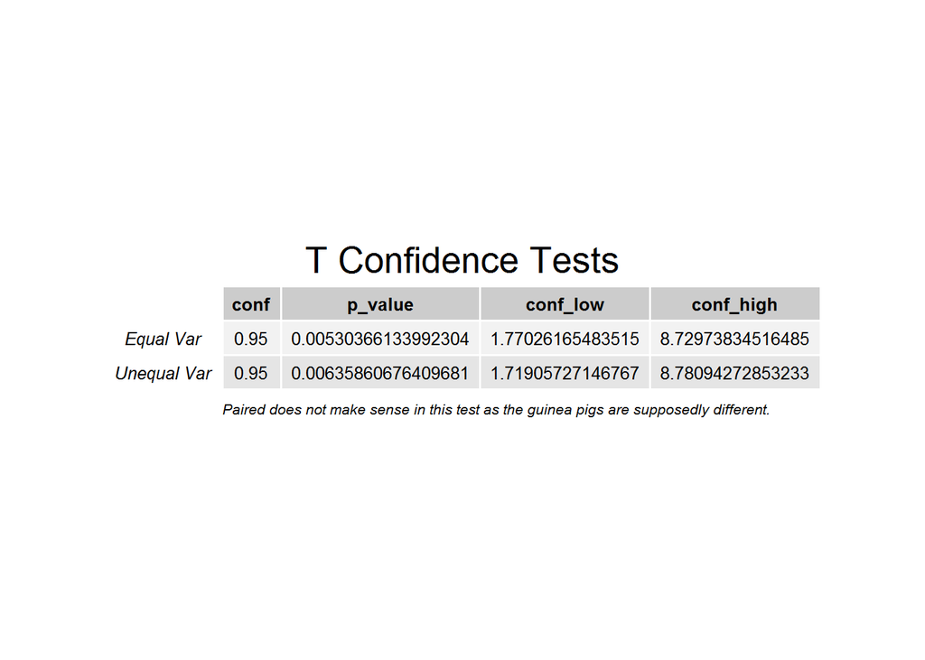

```r
  mytheme <- gridExtra::ttheme_default(
      core = list(fg_params=list(cex = .8)),
      colhead = list(fg_params=list(cex = .8)),
      rowhead = list(fg_params=list(cex = .8)))

  table <- gridExtra::tableGrob(result, theme = mytheme)
  title <- textGrob("T Confidence Tests",gp=gpar(fontsize=20))

  footnote <- textGrob("Paired does not make sense in this test as the guinea pigs are supposedly different. ", x=0, hjust=0,
                       gp=gpar( fontface="italic",fontsize=8))
  padding <- unit(1,"line")
  table <- gtable_add_rows(table,
                           heights = grobHeight(title) + padding,
                           pos = 0)
  table <- gtable_add_rows(table,
                           heights = grobHeight(footnote)+padding)

  table <- gtable_add_grob(table, list(title,footnote),
                           t=c(1, nrow(table)), l=c(1,2),
                           r=ncol(table))

  grid.newpage()
  grid.draw(table)
```

#### 4.) State your conclusions and the assumptions needed for your conclusions.

Assumptions: *There is a coorilation of tooth length in guinea pigs to vitamin C* This is a random sample of guinea pigs *60 is a large enough sample size